# Part I - Ford GoBike System Data

## Introduction

This data set contains information about individual rides made in a bike-sharing system covering the greater San Francisco Bay area. The data set has information on

Duration of the bike rides in seconds

Start_time of the ride

End_time of the ride

Start station id

Start station name

Start station's latitude

Start station's longitude

End station id

End station name

End station's latitude

End station's longitude

Bike id

User type: subscriber or customer

Member birth year

Member gender

Bike share for all trip

## Preliminary Wrangling

```python
# import all packages and set plots to be embedded inline
import numpy as np
import pandas as pd
import matplotlib.pyplot as plt
import seaborn as sb

from typing import List, Optional

%matplotlib inline
```

```python
#helper functions

# def plot_count(col_list: List[str],
#               df:pd.DataFrame,
#                hue: Optional[str] = None):

#     for col in col_list:
#         plt.figure(figsize=(20, 5))
#         sb.countplot(x=col, data=df,
#                      hue=hue, order=df[col].value_counts().index)
#         plt.title(f"{col} distribution")
#         plt.show()


# def plot_hist_count(col_list: List[str],
#                df: pd.DataFrame,
#                hue: Optional[str] = None,
#                stat:Optional[str] = None,
#                multiple:Optional[str] = None):

#     for col in col_list:
#         plt.figure(figsize=(20, 5))
#         sb.histplot(x=col, data=df,
#                       hue=hue, stat=stat,
#                       multiple=multiple)
#         plt.title(f"cat plot for {col} distribution")
#         plt.show()

# def plot_distribution(df: pd.DataFrame, col:List[str],
#                       hue: Optional[str] = None):

#     for col in col:
#         plt.figure(figsize=(20, 5))
#         sb.displot(data=df, x=col, hue=hue)
#         plt.title(f"Plot for {col} distribution")
#         plt.show()
```

Load in your dataset and describe its properties through the questions below. Try and motivate your exploration goals through this section.

```python
data = pd.read_csv('201902-fordgobike-tripdata.csv')
```

```python
data.head()
```

|  | duration_sec | start_time | end_time | start_station_id | start_station_name | start_station_latitude | start_station_longitude | end_station_id | end_station_name | end_station_latitude | end_station_longitude | bike_id | user_type | member_birth_year | member_gender | bike_share_for_all_trip |
| --- | --- | --- | --- | --- | --- | --- | --- | --- | --- | --- | --- | --- | --- | --- | --- | --- |
| 0 | 52185 | 2019-02-28 17:32:10.1450 | 2019-03-01 08:01:55.9750 | 21.0 | Montgomery St BART Station (Market St at 2nd St) | 37.789625 | -122.400811 | 13.0 | Commercial St at Montgomery St | 37.794231 | -122.402923 | 4902 | Customer | 1984.0 | Male | No |
| 1 | 42521 | 2019-02-28 18:53:21.7890 | 2019-03-01 06:42:03.0560 | 23.0 | The Embarcadero at Steuart St | 37.791464 | -122.391034 | 81.0 | Berry St at 4th St | 37.775880 | -122.393170 | 2535 | Customer | NaN | NaN | No |
| 2 | 61854 | 2019-02-28 12:13:13.2180 | 2019-03-01 05:24:08.1460 | 86.0 | Market St at Dolores St | 37.769305 | -122.426826 | 3.0 | Powell St BART Station (Market St at 4th St) | 37.786375 | -122.404904 | 5905 | Customer | 1972.0 | Male | No |
| 3 | 36490 | 2019-02-28 17:54:26.0100 | 2019-03-01 04:02:36.8420 | 375.0 | Grove St at Masonic Ave | 37.774836 | -122.446546 | 70.0 | Central Ave at Fell St | 37.773311 | -122.444293 | 6638 | Subscriber | 1989.0 | Other | No |
| 4 | 1585 | 2019-02-28 23:54:18.5490 | 2019-03-01 00:20:44.0740 | 7.0 | Frank H Ogawa Plaza | 37.804562 | -122.271738 | 222.0 | 10th Ave at E 15th St | 37.792714 | -122.248780 | 4898 | Subscriber | 1974.0 | Male | Yes |

```python
# Helper function to inspect and assess the data characteristics
def get_data_summary(data):
    summary = pd.concat([data.dtypes, data.nunique(),
                         data.count(), data.isnull().sum()],
                        keys=["dtypes", "nunique", "count", "missing"],
                        axis=1)
    return summary
```

```python
print(data.shape)
get_data_summary(data)
```

```
(183412, 16)
```

|  | dtypes | nunique | count | missing |
| --- | --- | --- | --- | --- |
| duration_sec | int64 | 4752 | 183412 | 0 |
| start_time | object | 183401 | 183412 | 0 |
| end_time | object | 183397 | 183412 | 0 |
| start_station_id | float64 | 329 | 183215 | 197 |
| start_station_name | object | 329 | 183215 | 197 |
| start_station_latitude | float64 | 334 | 183412 | 0 |
| start_station_longitude | float64 | 335 | 183412 | 0 |
| end_station_id | float64 | 329 | 183215 | 197 |
| end_station_name | object | 329 | 183215 | 197 |
| end_station_latitude | float64 | 335 | 183412 | 0 |
| end_station_longitude | float64 | 335 | 183412 | 0 |
| bike_id | int64 | 4646 | 183412 | 0 |
| user_type | object | 2 | 183412 | 0 |
| member_birth_year | float64 | 75 | 175147 | 8265 |
| member_gender | object | 3 | 175147 | 8265 |
| bike_share_for_all_trip | object | 2 | 183412 | 0 |

### What is the structure of your dataset?

The dataset contains 183,412 bike rides records with 16 characteristics (duration_sec, start_time, end_time, start_station_id, start_station_name, start_station_latitude, start_station_longitude, end_station_id, end_station_name, end_station_latitude, end_station_longitude, bike_id, user_type, member_birth_year, member_gender, bike_share_for_all_trip). The dataset has both numeric and categorical variables

### What is/are the main feature(s) of interest in your dataset?

Average duration of bike rides

Age and gender distribution of riders

Time of the day majority of the rides were taken

Association between user type and the duration of rides

### What features in the dataset do you think will help support your investigation into your feature(s) of interest?

Duration_sec

Member_birth_year

Member_gender

Start_time

user_type

Perform some data wrangling to make the data set tidy for analysis of interest

```python
# Convert bike ride duration in seconds to minutes
data['duration_mins'] = round((data.duration_sec)/60)
```

```python
# Convert start and end time to datetime format so as to be able to extract the time of day the ride was taken
data['start_time'] = pd.to_datetime(data['start_time'])
data['end_time'] = pd.to_datetime(data['end_time'])
```

```python
# Extract the hour of the day the ride started
data['time']= data['start_time'].dt.hour
```

```python
# Categorize the hour into time of the day
b = [0,6,12,18,24]
l = ['Late Night','Morning','Afternoon','Night']
data['time_of_day'] = pd.cut(data['time'], bins=b, labels=l, include_lowest=True)

# Define the variable inputs
def f(x):
    if (x > 6) and (x <= 12 ):
        return 'Morning'
    elif (x > 12) and (x <= 18):
        return'Afternoon'
    elif (x > 18) and (x <= 24):
        return'Night'
    elif (x <= 6):
        return'Late Night'

# Create the time of day variable
data['time_of_day'] = data['time'].apply(f)
```

```python
# Extract weekday from start time
import datetime
import calendar

def weekday_from_date(year,month, day):
    return calendar.day_name[
        datetime.date(year=year, month=month, day=day).weekday()
    ]
data['year'] = data['start_time'].dt.year
data['month'] = data['start_time'].dt.month
data['day'] = data['start_time'].dt.day

data['weekday'] = data.apply(lambda x: weekday_from_date(x['year'], x['month'], x['day']), axis=1)
```

```python
# descriptive statistics for numeric variables
data.describe()
```

|  | duration_sec | start_station_id | start_station_latitude | start_station_longitude | end_station_id | end_station_latitude | end_station_longitude | bike_id | member_birth_year | duration_mins | time | year | month | day |
| --- | --- | --- | --- | --- | --- | --- | --- | --- | --- | --- | --- | --- | --- | --- |
| count | 183412.000000 | 183215.000000 | 183412.000000 | 183412.000000 | 183215.000000 | 183412.000000 | 183412.000000 | 183412.000000 | 175147.000000 | 183412.000000 | 183412.000000 | 183412.0 | 183412.0 | 183412.000000 |
| mean | 726.078435 | 138.590427 | 37.771223 | -122.352664 | 136.249123 | 37.771427 | -122.352250 | 4472.906375 | 1984.806437 | 12.101340 | 13.458421 | 2019.0 | 2.0 | 15.298977 |
| std | 1794.389780 | 111.778864 | 0.099581 | 0.117097 | 111.515131 | 0.099490 | 0.116673 | 1664.383394 | 10.116689 | 29.908512 | 4.724978 | 0.0 | 0.0 | 8.028187 |
| min | 61.000000 | 3.000000 | 37.317298 | -122.453704 | 3.000000 | 37.317298 | -122.453704 | 11.000000 | 1878.000000 | 1.000000 | 0.000000 | 2019.0 | 2.0 | 1.000000 |
| 25% | 325.000000 | 47.000000 | 37.770083 | -122.412408 | 44.000000 | 37.770407 | -122.411726 | 3777.000000 | 1980.000000 | 5.000000 | 9.000000 | 2019.0 | 2.0 | 8.000000 |
| 50% | 514.000000 | 104.000000 | 37.780760 | -122.398285 | 100.000000 | 37.781010 | -122.398279 | 4958.000000 | 1987.000000 | 9.000000 | 14.000000 | 2019.0 | 2.0 | 15.000000 |
| 75% | 796.000000 | 239.000000 | 37.797280 | -122.286533 | 235.000000 | 37.797320 | -122.288045 | 5502.000000 | 1992.000000 | 13.000000 | 17.000000 | 2019.0 | 2.0 | 22.000000 |
| max | 85444.000000 | 398.000000 | 37.880222 | -121.874119 | 398.000000 | 37.880222 | -121.874119 | 6645.000000 | 2001.000000 | 1424.000000 | 23.000000 | 2019.0 | 2.0 | 28.000000 |

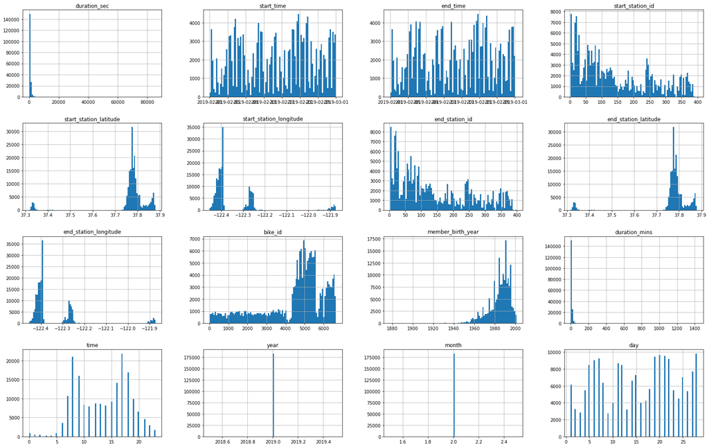

```python
# Explore the general distribution of features in the data set
data.hist(figsize=(28,18), bins=100);
```

## Univariate Exploration

First, explore the distribution of the variable of interest : bike ride duration in minutes

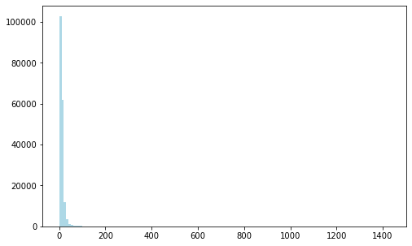

```python
# start with a standard-scaled plot
plt.figure(figsize = [8, 5])  #Define the figure size
bins = np.arange(0, data['duration_mins'].max()+10, 10)
plt.hist(data['duration_mins'], bins = bins, color='lightblue');
```

The data is skewed to the right and clustered up because it contains very large outliers; to better visualize the distribution we can change the axis limit to address the outliers as well as use a logscale

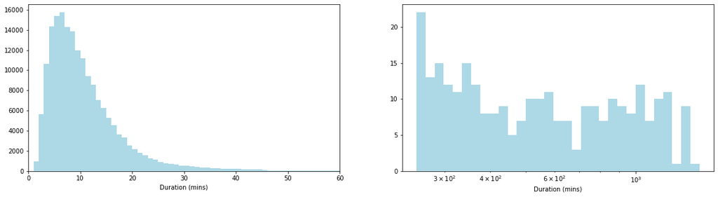

```python
# Plot the histogram with a changed axis limit.
plt.figure(figsize = [20, 5])

# histogram on left: axis limit
plt.subplot(1, 2, 1)
bin_edges = np.arange(0, data['duration_mins'].max()+1, 1)
plt.hist(data=data, x='duration_mins', bins = bin_edges, color='lightblue')
plt.xlabel('Duration (mins)')
plt.xlim(0, 60)

# histogram on right: log scale
plt.subplot(1, 2, 2)
log_binsize = 0.025
bins = 10 ** np.arange(2.4, np.log10(data['duration_mins'].max())+log_binsize, log_binsize)
plt.hist(data = data, x = 'duration_mins', bins = bins, color='lightblue')
plt.xscale('log')
plt.xlabel('Duration (mins)')
plt.show()
```

From the above, we notice that majority of the bike rides lasted for about 1-20 minutes, few rides lasted for 20-40 minutes, there were a lot less rides that lasted for more than 40mins

Next up, we explore an important characteristic of the bike riders(Age)

```python
data['member_birth_year'].describe()
```

```
count    175147.000000
mean       1984.806437
std          10.116689
min        1878.000000
25%        1980.000000
50%        1987.000000
75%        1992.000000
max        2001.000000
Name: member_birth_year, dtype: float64
```

```python
# Create the age variable for members
from datetime import date

current_year = date.today().year

data['Age'] = current_year - data['member_birth_year']
```

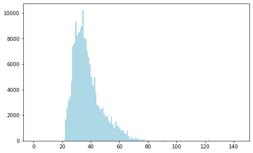

```python
plt.figure(figsize = [8, 5])  #Define the figure size
bins = np.arange(0, data['Age'].max()+1, 1)
plt.hist(data['Age'], bins = bins, color='lightblue');
```

We observe that the bike riders are mostly between ages 20-80 with majority being between 20-40 with a few riders older than 80, the avarage age of bike riders is about 37 . we can also obsevere there are some oulier ages above 100 which may be an entry error

Next we explore the distribution of some other features

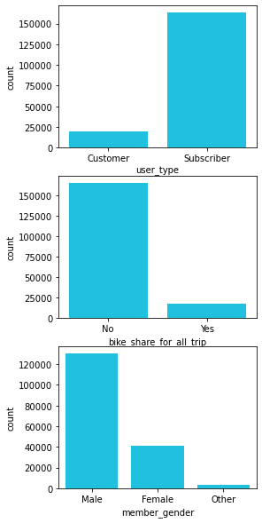

```python
# Explore the distribution of some categorical features
fig, ax = plt.subplots(nrows=3, figsize = [4,10])

default_color = sb.color_palette('bright')[9]
sb.countplot(data = data, x = 'user_type', color = default_color, ax = ax[0])
sb.countplot(data = data, x = 'bike_share_for_all_trip', color = default_color, ax = ax[1])
sb.countplot(data = data, x = 'member_gender', order=('Male', 'Female', 'Other'),color = default_color, ax = ax[2])

plt.show()
```

From the above we notice that majority of the bike rides were taken by subcribers, most of the riders were male and most of the rides were not a bike share for all trip

Next we explore some ordinal features

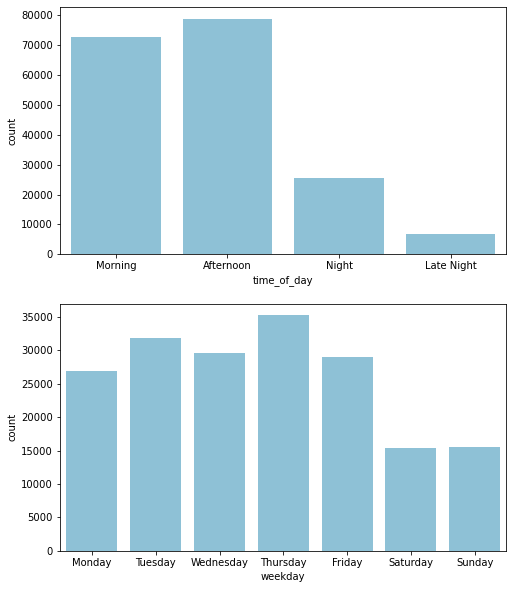

```python
# Explore the distribution of some ordinal features
fig, ax = plt.subplots(nrows=2, figsize = [8,10])
default_color = sb.color_palette('muted')[9]
sb.countplot(data = data, x = 'time_of_day',order=('Morning','Afternoon', 'Night', 'Late Night'),color = default_color, ax = ax[0]);
sb.countplot(data = data, x = 'weekday',order= ('Monday', 'Tuesday', 'Wednesday', 'Thursday', 'Friday', 'Saturday', 'Sunday'),
             color = default_color, ax = ax[1]);
```

Here we aim to explore bike rides at different times of the day and of the week to see if there are differences, majority of the bike rides are taken during the day with most rides being in the afternoon(12-6pm) and very few rides taken night. looking across the days of the week, we see that most bikes rides are taken during the weekdays and bike rides drop significantly on weekends, worthy to note is that Thursdays and tuesdays have the highest number of rides

Another Feature of that might be worth exploring is the bike stations and bike station routes

```python
import warnings
warnings.filterwarnings('ignore')
```

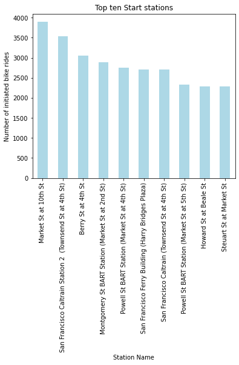

```python
#Explore the top 10 stations with the highest number of initiated bike rides
data['start_station_name'].value_counts()[:10].plot(kind='bar',
                                                 figsize=(6, 5),
                                                 xlabel ='Station Name',
                                                 ylabel='Number of initiated bike rides',
                                                 title='Top ten Start stations',
                                                 color='lightblue');
```

We can see here that Market station at 10th street has the highest bike ride initiation,

Next we explore the most popular routes

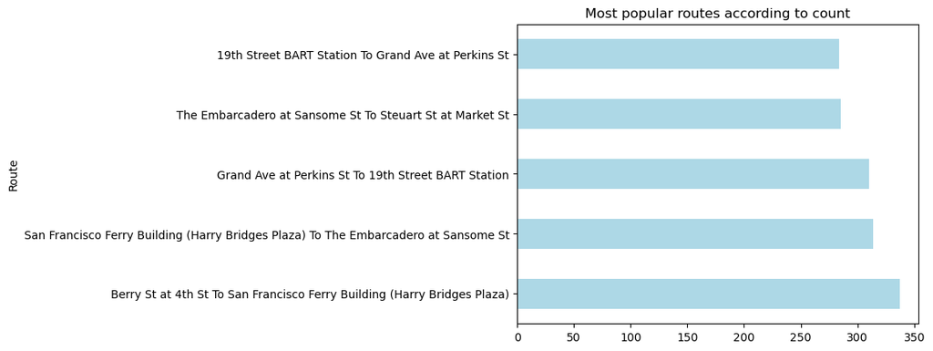

```python
# Create routes by joining start and end station
data_location = data.filter(['start_station_name', 'end_station_name'])
data_location['data_location_desc'] = data_location['start_station_name'] +" " + "To" + " " + data_location['end_station_name']
plt.rcdefaults()
#y = np.array([])

cmap = plt.get_cmap('viridis')
rescale = lambda y: (y-np.min(y)) / (np.max(y) - np.min(y))

# Plot routes with the highest frequencies
data_location['data_location_desc'].value_counts()[:5].plot(kind='barh',
                                                        xlabel= 'Route',
                                                        ylabel= 'Frequency',
                                                        title='Most popular routes according to count',
                                                        color='lightblue');
```

The most popular bike route is Berry St at 4th St To San Francisco Ferry Building (Harry Bridges Plaza)

### Discuss the distribution(s) of your variable(s) of interest. Were there any unusual points? Did you need to perform any transformations?

The duration of bike rides is skewed to the right with most of the bike rides ranging between 1-20 mins, however there is a steady decline in the number of bike rides after about 10 minutes. There is also some really large outliers in this variable The average age of bike riders is 37 years and most of the riders are male some transformation was done on the data using axis limit and log transform, applying the axis limit better showcased the distribution of the data without the outliers

### Of the features you investigated, were there any unusual distributions? Did you perform any operations on the data to tidy, adjust, or change the form of the data? If so, why did you do this?

I invitigated other features like time of the day and week of the bike rides, to do this start time was wrangled to extract time of the day and weekday of each ride.The bike stations and routes were also explored to investigate any interesting insights

## Bivariate Exploration

To start off with, I want to look at the pairwise correlations present between features in the data.

```python
# Remove some unnecessary colunmns
cols_to_remove = [
    'start_station_id', 'end_station_id',
    'bike_id', 'year', 'month', 'duration_sec'
]

df = data.drop(cols_to_remove, axis=1)
```

```python
numeric_vars = df.select_dtypes(include=['float', 'int'])
```

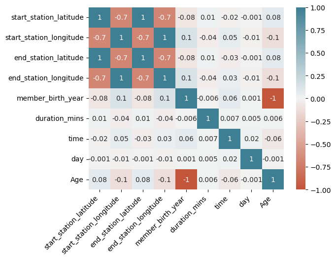

```python
# Correlation plot
corr = numeric_vars.corr()
ax = sb.heatmap(
    corr,
    vmin=-1, vmax=1, center=0,
    cmap=sb.diverging_palette(20, 220, n=200),
    annot=True, fmt=".0g"
)
ax.set_xticklabels(
    ax.get_xticklabels(),
    rotation=45,
    horizontalalignment='right'
);
```

First we explore relationships between Age / Member_Gender vs time_of_day

```python
# First of all drop observations with no age
df = df.dropna(subset='Age')
```

```python
# Group age into age groups to make it easier to look at the reationship
conds = [
    (df['Age'] >20) & (df['Age'] <= 40),
    (df['Age'] > 40) & (df['Age'] <=60),
    (df['Age'] > 60),
]
choices = ['20 - 40', '40 - 60', '>60']
df['Age_Group'] = np.select(conds, choices)
```

```python
df['Age_Group'].value_counts()
```

```
20 - 40    125116
40 - 60     44249
>60          5782
Name: Age_Group, dtype: int64
```

```python
sample_data = df.sample(n=2000, random_state=42)
```

```python
# plt.scatter(data = sample_data, x = 'Age', y = 'duration_mins', alpha = 1/10);
# plt.yscale('log')
# plt.yticks([1, 1e1, 1e2, 1e3], [ '20', '40', '60', '80'])
```

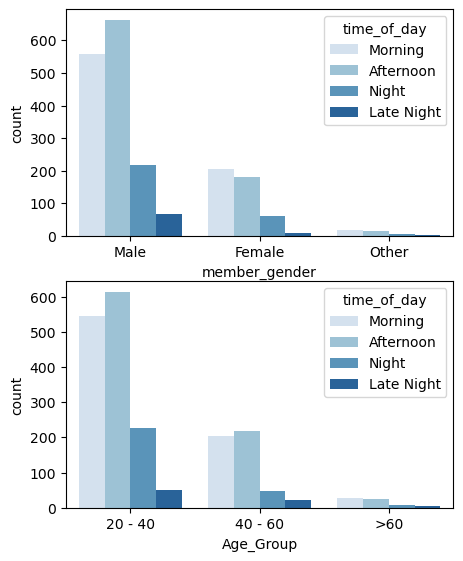

```python
# since there's only three subplots to create, using the full data should be fine.
plt.figure(figsize = [5, 10])

# subplot 1: gender vs time of day
plt.subplot(3, 1, 1)
sb.countplot(data = sample_data, x = 'member_gender',hue='time_of_day', palette = 'Blues',
             order=('Male', 'Female', 'Other'), hue_order= ('Morning','Afternoon', 'Night', 'Late Night'))


# subplot 2: Age vs. time of day
ax = plt.subplot(3, 1, 2)
sb.countplot(data = sample_data, x = 'Age_Group',hue='time_of_day',palette = 'Blues',
            order= ('20 - 40', '40 - 60', '>60'), hue_order= ('Morning','Afternoon', 'Night', 'Late Night'))
plt.show()
```

There's not much interactions between gender and time of the day bike rides are taken nor any interaction between age and time of the day bike rides are taken

Next, Explore relationships between the variable of interest duration of bike rides and time of day/age group/gender/user type

```python
sample_data = df.sample(n=2000, replace = False)
def build_boxplots(data: pd.DataFrame,
                  x_feature:str,
                  y_feature:str,
                  ):
    plt.figure(figsize=(7,4))
    ax = sb.boxplot(data=data, x=x_feature, y=y_feature)
    ax.set_ylim(0, 60)
    plt.title(f"Distribution of minutes spent according to {feature}")
    plt.show()
```

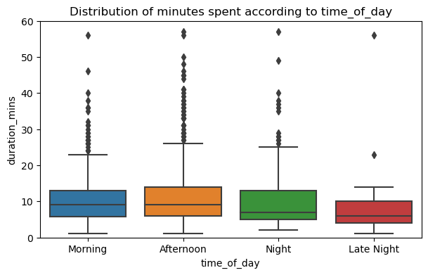

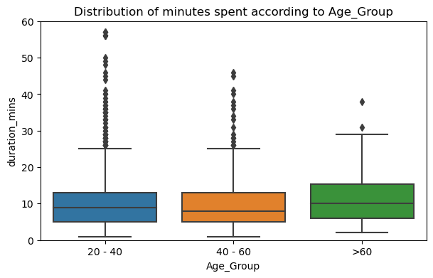

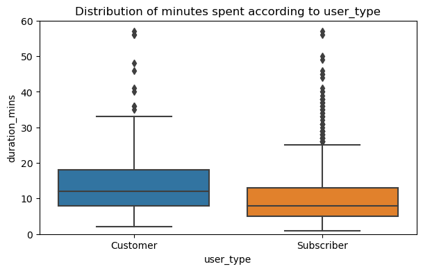

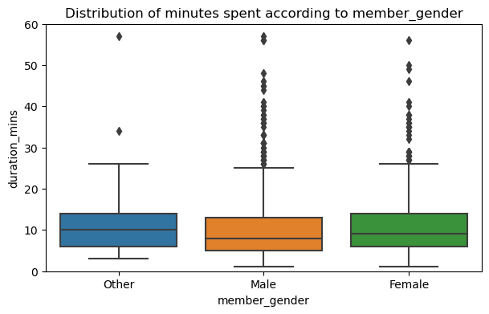

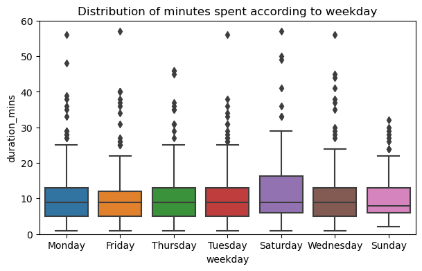

```python
x_features = ['time_of_day','Age_Group', 'user_type','member_gender', 'weekday']
y_feature = 'duration_mins'

for feature in x_features:
    build_boxplots(sample_data, feature, y_feature)
```

### Talk about some of the relationships you observed in this part of the investigation. How did the feature(s) of interest vary with other features in the dataset?

There's not much interactions between gender and time of the day bike rides are taken nor any interaction between age and time of the day bike rides are taken

### Did you observe any interesting relationships between the other features (not the main feature(s) of interest)?

Exploring the interaction between duration and user type, Customers rode longer than subscribers

## Multivariate Exploration

The main thing I want to explore in this part of the analysis is how the categorical features play into the relationship with duration in minutes

First we look at the relationship between duration in minutes, age and gender

```python
new_sample = df.sample(n=10000, random_state=42)
```

```python
new_sample['duration_mins'].describe()
```

```
count    10000.00000
mean        11.64300
std         21.67509
min          1.00000
25%          5.00000
50%          9.00000
75%         13.00000
max        899.00000
Name: duration_mins, dtype: float64
```

```python
# Remove outliers to better explore the interactions
new_sample_without_outlier = new_sample[new_sample['duration_mins'] <= 90]
```

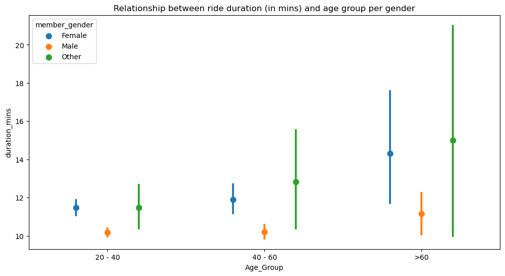

```python
fig, ax = plt.subplots(figsize = [12,6])
sb.pointplot(data = new_sample_without_outlier, x = 'Age_Group', y = 'duration_mins', hue = 'member_gender',
             palette = sb.color_palette('tab10'), linestyles = '', dodge = 0.4,
            order=['20 - 40', '40 - 60', '>60'])
plt.title("Relationship between ride duration (in mins) and age group per gender")
```

From the above we observe that the duration of rides increase as age increases across all genders. However, males have the lowest ride time across the all a groups.

Next we explore the interactions between bike ride duration, the day of the week and time of day

```python
#sample_data = df_Age.sample(n=2000, random_state=42)
```

```python
cols = ['time_of_day', 'duration_mins', 'weekday']

sample_data_f = new_sample.filter(cols)
```

```python
sample_data_f = sample_data_f[~(sample_data_f['duration_mins']>60)]
```

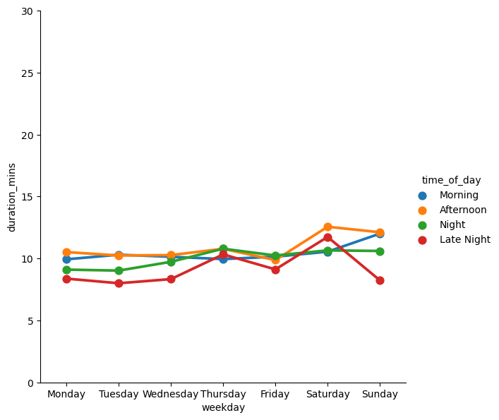

```python
ax = sb.catplot(x='weekday',
          y='duration_mins',
          hue='time_of_day',
          data=sample_data_f,
          kind='point',
          height=6,
          ci=None,
          order= ('Monday', 'Tuesday', 'Wednesday', 'Thursday', 'Friday', 'Saturday', 'Sunday'),
          hue_order=['Morning', 'Afternoon', 'Night', 'Late Night'])
ax.set(ylim=(0,30));
```

Next we explore the interactions between the number of bike rides and day of the week and time of the day

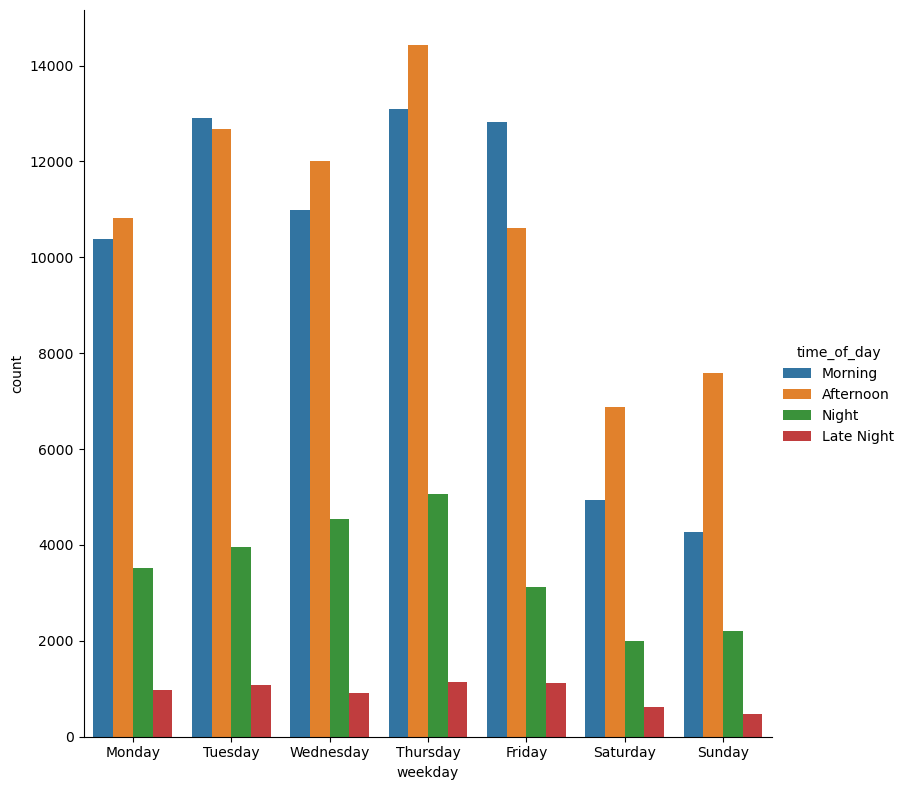

```python
ax = sb.catplot(x='weekday',
          hue='time_of_day',
          data=df,
          kind='count',
          height=8,
          # ci=None,
          order= ('Monday', 'Tuesday', 'Wednesday', 'Thursday', 'Friday', 'Saturday', 'Sunday'),
          hue_order=['Morning', 'Afternoon', 'Night', 'Late Night'])
# ax.set(ylim=(0,60))
```

From the above, just as we have observed from previous exploration most bike rides were taken in the day(morning and afternoon) with more taken in the afternoon compared to at night and this is the same across all days of the week. Just a slight difference on tuesday and fridays where most rides were taken in the morning

### Talk about some of the relationships you observed in this part of the investigation. Were there features that strengthened each other in terms of looking at your feature(s) of interest?

from the interactions between duration of bike ride and weekday and time of day, the day a ride was taken didn't significantly change the duration of the rides. Showing that riders ride for almost the same amount of time on different days during the same time of the day

### Were there any interesting or surprising interactions between features?

The interactions between duration of bike rides and age differed among different genders showing that while age has a effect on the bike ride duration, the gender of the rider in a similar age group also has an effect

## Conclusions

There were more male riders and the average age of the rider was between 20-40 years.

There were also more bike rides during the day than at night and more on weekdays than on weekends.

I found that there was a relationship between the time of day a ride of day was taken and the duration of time. Riders rode longer during the day than at night

However the day of the week did not have much effect on the average duration of bike rides. The duration of rides increased as age increased across all genders. However, males have the lowest ride time across the all a groups.